# CP QuanteR

Ingus Perkons

2/15/2023

## Note

Peak integration is done in Skyline.

# Code (version R 4.1.1.)

## Load libraries

```r
library(readxl)
library(stringr)
library(stringi)
library(ggplot2)
library(tidyr)
library(dplyr)
library(knitr)
library(xlsx)
library(ggthemes)
library(broom)
library(ggpmisc)
library(gridExtra)
```

## Define variables

### Define file name for the XLSX export, where the results of the data analysis will be stored

```r
temp.xlsx.filename = "Excel_data_report"
```

### Define file name of the exported peak integration data (.csv) from Skyline

Note: the Skyline report must contain the following columns:

- “Product.Mz” - m/z values of CPs
- “Area” - peak areas of CPs
- “Replicate” - file names of the instrumental data files

Example table from Skyline .csv report

[output not shown]

```r
temp.csv.filename = "Skyline_export"
```

### Define the volume of the final sample extract (μL)

```r
Final.extract.volume = 100 #μL
```

### Define the molecular formula of the internal standard compound

```r
ISTD.formula = "C'10Cl6H16"
```

## Read external files

**All files must be placed in the same folder as the .Rmd file of the analysis**  
To enable reading from the same folder as the .Rmd file is located:  
*Session –> Set Working Directory –> To Source File Location*

### Read sequence and mass-list (both must be placed in the same folder of .R file)

```r
LC.input <- read_xlsx("Reference_sheet.xlsx", sheet = 3)
LC.input = LC.input %>% mutate(ID.name = paste(molecular.formula,"-",round(m.z), sep = "")) %>% select(-m.z,-adduct)
LC.sequence.1M <- read_xlsx("Reference_sheet.xlsx", sheet = 1)
```

### Read .csv export from SkyLine

```r
store.lc <- read.csv(paste(temp.csv.filename,".csv",sep = ""),sep = ",",header = T)
store.lc = store.lc %>% select(Precursor.Neutral.Formula,Product.Mz,Area,Replicate) %>%
  mutate(m.z = Product.Mz, peak.area = Area) %>% mutate(ID.name = paste(Precursor.Neutral.Formula,"-",round(m.z), sep = "")) %>% select(-Product.Mz,-Area)
store.lc = left_join(store.lc,LC.sequence.1M, by = "Replicate")
store.lc = left_join(store.lc,LC.input, by = "ID.name")
store.lc = store.lc %>%
  ungroup() %>%
  mutate(peak.area = ifelse(peak.area == "#N/A",NA,peak.area)) %>%
  mutate(peak.area = as.numeric(peak.area)) %>%
  group_by(Replicate) %>% mutate(ISTD.area = ifelse(molecular.formula == ISTD.formula,peak.area,0)) %>%
  mutate(ISTD.area = max(ISTD.area, na.rm = TRUE)) %>%
  ungroup() %>%
  mutate(molecular.formula = ifelse(molecular.formula == ISTD.formula,"ISTD",molecular.formula)) %>%
  filter(is.na(retention.time) != TRUE) %>%
  select(m.z,retention.time,row.identity,molecular.formula,peak.area,Sample.name, Sample.type, ISTD.area)
```

### Backup unprocessed input data

```r
store.lc.1M <- store.lc
```

## Prepare data tables for quantification procedure

### Add carbon chain length and Cl number

Note:  
Here only Cl numbers from 4 to 12 Cl atoms per CP homologue group are evaluated  
Line `mutate(Cl.No = factor(Cl.No, levels = c("4","5","6","7","8","9","10","11","12")))` has to be changed to increase or decrease number of Cl atoms used in the following workflow.

```r
store.lc.1M = store.lc.1M %>%
  ungroup() %>%
  mutate(Chain.length = str_remove(substr(molecular.formula, start=1, stop=3),pattern = "C")) %>%
  mutate(Cl.No = substr(molecular.formula,
                        start=(unlist(str_locate(molecular.formula,"Cl"))+2),
                        stop=str_length(molecular.formula))) %>%
  mutate(Cl.No = factor(Cl.No, levels = c("4","5","6","7","8","9","10","11","12")))
```

## Export the unprocessed data as an XLSX file

Exported file will contain information about peak identities, peak areas, Cl and C numbers aggregated by sample type (i.e, Sample, Blank, QC, Calibration)

| m.z | retention.time | row.identity | molecular.formula | Sample.type | Chain.length | Cl.No | Pork 1 | Pork 2 | Pork 3 |
| --- | --- | --- | --- | --- | --- | --- | --- | --- | --- |
| 392.9383 | 9.6 | 000_ISTD | ISTD | Sample | IST | NA | 441710848 | 437027360 | 388715072 |
| 314.9827 | 10.0 | 015_SCCP_C10H18Cl4_[M+Cl] | C10H18Cl4 | Sample | 10 | 4 | 13360312 | 12133622 | 17943702 |
| 348.9438 | 10.0 | 017_SCCP_C10H17Cl5_[M+Cl] | C10H17Cl5 | Sample | 10 | 5 | 159155856 | 192515296 | 247904736 |
| 382.9048 | 10.0 | 019_SCCP_C10H16Cl6_[M+Cl] | C10H16Cl6 | Sample | 10 | 6 | 170313984 | 179318304 | 271060736 |
| 418.8629 | 10.0 | 021_SCCP_C10H15Cl7_[M+Cl] | C10H15Cl7 | Sample | 10 | 7 | 76298328 | 65724872 | 113680464 |

### Normalize peak areas using internal standard

```r
store.lc.1M = store.lc.1M %>%
    mutate(Peak.area.ratio = peak.area/ISTD.area)
```

### Graph internal standard peak areas to check for sample inconsistencies

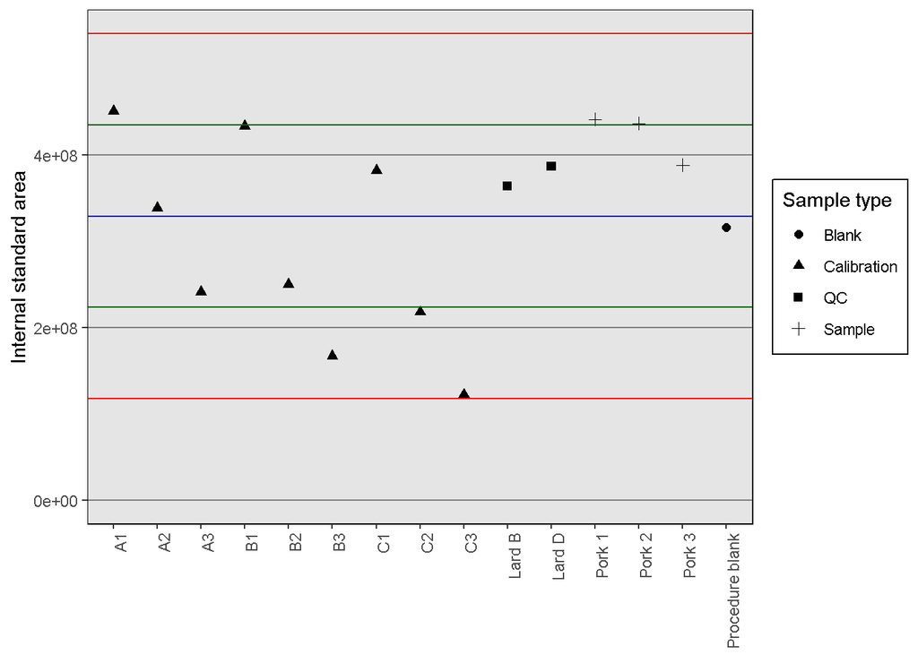

### Blank assignment and subtraction using a pre-defined assignment of blanks from “Reference_sheet.xlsx”

Blank subtraction is not conducted for *Calibration* samples and samples that do not have an assigned blank file from the Reference_sheet.xlsx file

```r
store.lc.blank.values = store.lc.1M %>%
  filter(Sample.type == "Blank") %>%
  group_by(molecular.formula, Sample.name) %>%
  mutate(Peak.area.ratio.mean = mean(Peak.area.ratio, na.rm = TRUE)) %>%
  select(molecular.formula,Peak.area.ratio.mean,Sample.name) %>%
  mutate(Peak.area.ratio.mean = ifelse(is.nan(Peak.area.ratio.mean)==TRUE,0,Peak.area.ratio.mean)) %>%
  unique(.)
store.lc.blank.values = left_join(store.lc.blank.values, read_xlsx("Reference_sheet.xlsx", sheet = 4), by = "Sample.name") %>%
  ungroup() %>%
  select(-Sample.name)

store.lc.1M = store.lc.1M %>%
  left_join(., read_xlsx("Reference_sheet.xlsx", sheet = 4), by = "Sample.name") %>%
  left_join(.,store.lc.blank.values, by = c("molecular.formula","Blank.sample")) %>%
  mutate(Peak.area.ratio.bs = ifelse(Sample.type != "Calibration",Peak.area.ratio-Peak.area.ratio.mean,Peak.area.ratio)) %>%
  mutate(Peak.area.ratio.bs = ifelse(Peak.area.ratio.bs>0,Peak.area.ratio.bs,0)) %>%
  select(-Peak.area.ratio.mean,-Blank.sample)
```

### Calculate relative distribution among homologue groups

```r
store.lc.1M =
store.lc.1M %>%
  filter(row.identity != "000_ISTD") %>%
  group_by(Sample.name, Chain.length) %>%
  mutate(Sum.chain.length.peak.area.ratio.bs = sum(Peak.area.ratio.bs, na.rm = TRUE)) %>%
  mutate(Sum.chain.length.peak.area.ratio = sum(Peak.area.ratio, na.rm = TRUE)) %>%
  ungroup() %>%
  group_by(Sample.name, Chain.length, Cl.No) %>%
  mutate(Relative.distribution.bs = Peak.area.ratio.bs/Sum.chain.length.peak.area.ratio.bs*100) %>%
  mutate(Relative.distribution = Peak.area.ratio/Sum.chain.length.peak.area.ratio*100)
```

### Calculate theoretical Cl% degrees of each C<sub>n</sub>Cl<sub>4-12</sub> homologoue groups

Example for $C_nH_{2n+2-m}Cl_m$:

${Cl\%}_{C_nH_{2n+2-m}Cl_m} = \frac{m*35.5}{n*12+2n+2-m+m*35.5}$

```r
store.lc.1M = store.lc.1M %>%
  mutate(Cl.degree = (as.numeric(as.character(Cl.No))*35.5)/(as.numeric(as.character(Cl.No))*35.5+as.numeric(as.character(Chain.length))*12+(as.numeric(as.character(Chain.length))*2+2)-as.numeric(as.character(Cl.No)))*100) %>%
  mutate(Cl.degree.impact.bs = Cl.degree * Relative.distribution.bs/100) %>%
  mutate(Cl.degree.impact = Cl.degree * Relative.distribution/100) %>%
  group_by(Sample.name,Chain.length) %>%
  mutate(Chain.Cl.degree.impact.bs = sum(Cl.degree.impact.bs, na.rm = TRUE)) %>%
  mutate(Chain.Cl.degree.impact = sum(Cl.degree.impact, na.rm = TRUE)) %>%
  select(-Cl.degree.impact.bs,-Cl.degree.impact.bs)

store.lc.1M = store.lc.1M %>% unique()
```

## Export processed data with peak area ratios and Cl% degrees as an Excel Output

### Output in excel by sample type (normalized by internal standard, **blank subtracted**)

| m.z | retention.time | row.identity | molecular.formula | Sample.type | Chain.length | Cl.No | Pork 1 | Pork 2 | Pork 3 |
| --- | --- | --- | --- | --- | --- | --- | --- | --- | --- |
| 314.9827 | 10 | 015_SCCP_C10H18Cl4_[M+Cl] | C10H18Cl4 | Sample | 10 | 4 | 0.0146200 | 0.0121373 | 0.0305349 |
| 348.9438 | 10 | 017_SCCP_C10H17Cl5_[M+Cl] | C10H17Cl5 | Sample | 10 | 5 | 0.1300661 | 0.2102601 | 0.4075036 |
| 382.9048 | 10 | 019_SCCP_C10H16Cl6_[M+Cl] | C10H16Cl6 | Sample | 10 | 6 | 0.1120141 | 0.1367497 | 0.4237611 |
| 418.8629 | 10 | 021_SCCP_C10H15Cl7_[M+Cl] | C10H15Cl7 | Sample | 10 | 7 | 0.0201338 | 0.0000000 | 0.1398521 |
| 452.8239 | 10 | 023_SCCP_C10H14Cl8_[M+Cl] | C10H14Cl8 | Sample | 10 | 8 | 0.0075413 | 0.0000000 | 0.0305416 |

### Output in excel by sample type (normalized by internal standard, **not blank subtracted**)

[output not shown]

## Calibration

### Create a separate data.frame for calibration

```r
store.lc.calibration = store.lc.1M %>%
  filter(Sample.type == "Calibration") %>%
  select(-Peak.area.ratio.bs,-Sum.chain.length.peak.area.ratio.bs,-Relative.distribution.bs,-Chain.Cl.degree.impact.bs)
```

### Read calibration information from “Reference_sheet.xlsx”

Information: calibration mixture code, concentration

```r
store.lc.calibration = left_join(x = store.lc.calibration, y= read_xlsx("Reference_sheet.xlsx", sheet = 2), by = "Sample.name")
```

Calibration data table from “Reference_sheet.xlsx”

| Sample.name | Calibration.level | Calibration.type | Chain.length.info |
| --- | --- | --- | --- |
| A1 | 0.5 | Calibration A | 10_11_12_13_14_15_16_17 |
| A2 | 2.0 | Calibration A | 10_11_12_13_14_15_16_17 |
| A3 | 4.0 | Calibration A | 10_11_12_13_14_15_16_17 |
| B1 | 0.5 | Calibration B | 10_11_12_13_14_15_16_17 |
| B2 | 2.0 | Calibration B | 10_11_12_13_14_15_16_17 |
| B3 | 4.0 | Calibration B | 10_11_12_13_14_15_16_17 |
| C1 | 0.5 | Calibration C | 10_11_12_13_14_15_16_17 |
| C2 | 2.0 | Calibration C | 10_11_12_13_14_15_16_17 |
| C3 | 4.0 | Calibration C | 10_11_12_13_14_15_16_17 |

### Drop unused homologoue groups (e.g., when a calibration mixture doesn’t contain MCCPs)

```r
store.lc.calibration = store.lc.calibration %>%
  mutate(Use.homologue.group = str_detect(as.character(Chain.length.info), as.character(Chain.length))) %>%
  filter(Use.homologue.group == TRUE)
```

### Extract R-squared values and calculate slope

intercept = 0 (forced to origin)

```r
temp.R.sq = store.lc.calibration %>%
  ungroup() %>%
  select(Calibration.type,Chain.length,Calibration.level,Sum.chain.length.peak.area.ratio) %>%
  unique() %>%
  group_by(Calibration.type,Chain.length) %>%
  do(InfoList = glance(lm(.,formula = Sum.chain.length.peak.area.ratio~Calibration.level-1))) %>%
  unnest(InfoList) %>%
  select(Calibration.type,Chain.length,r.squared)

temp.Slope = store.lc.calibration %>%
  ungroup() %>%
  select(Calibration.type,Chain.length,Calibration.level,Sum.chain.length.peak.area.ratio) %>%
  unique() %>%
  group_by(Calibration.type,Chain.length) %>%
  do(InfoList = tidy(lm(.,formula = Sum.chain.length.peak.area.ratio~Calibration.level-1))) %>%
  unnest(InfoList) %>%
  select(Calibration.type,Chain.length,estimate) %>%
  mutate(Slope = estimate) %>%
  select(-estimate)

store.lc.calibration = left_join(store.lc.calibration,
          left_join(temp.Slope,temp.R.sq,by = c("Calibration.type","Chain.length")),by = c("Calibration.type","Chain.length"))
rm(temp.R.sq,temp.Slope)
```

### Create calibration plots and export as .pdf

If there are vSCCPs, LCCPs or vLCCPs implemented in the workflow, the following for loop has to be adjusted  
For example, if only SCCPs are used: `for (i in 10:13)` or if vSCCPs/SCCPs/MCCPs are used: `for (i in 9:17)`

Example

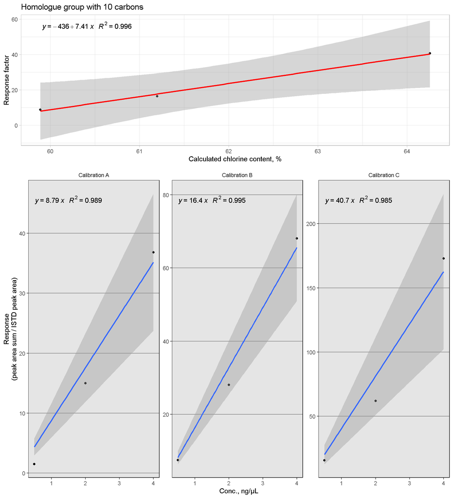

### Fetch R-squared and slope values from calibration and join with main dataset

```r
temp.R.sq = Calibration.main %>%
  group_by(Chain.length) %>%
  do(InfoList = glance(lm(.,formula = Slope~Chain.Cl.degree.impact))) %>%
  unnest(InfoList) %>%
select(Chain.length,r.squared)

temp.Slope = Calibration.main %>%
  group_by(Chain.length) %>%
  do(InfoList = tidy(lm(.,formula = Slope~Chain.Cl.degree.impact))) %>%
  unnest(InfoList)%>%
  select(Chain.length,term,estimate) %>%
  mutate(term = ifelse(term == "Chain.Cl.degree.impact","Slope","Intercept"))%>%
  spread(term,estimate)

Calibration.main = left_join(Calibration.main %>% select(-Slope,-r.squared),
                                 left_join(temp.Slope,temp.R.sq,by = c("Chain.length")),by = c("Chain.length"))
rm(temp.R.sq,temp.Slope)

Calibration.main = Calibration.main %>%
  ungroup() %>%
  select(-Chain.Cl.degree.impact,-Calibration.type) %>%
  unique()
```

## Quantification of samples

### Create data frame for results and join with sample and calibration data

```r
Results.sheet = store.lc.1M %>% filter(Sample.type != "Calibration") %>%
  select(Sample.name,Sample.type,Chain.length,Sum.chain.length.peak.area.ratio,Sum.chain.length.peak.area.ratio.bs,
         Chain.Cl.degree.impact, Chain.Cl.degree.impact.bs) %>%
  unique()

Results.sheet = left_join(Results.sheet,Calibration.main, by = "Chain.length") %>%
  mutate(CP.type = ifelse(Chain.length %in% c(10,11,12,13),"SCCPs",ifelse(Chain.length %in% c(14,15,16,17),"MCCPs","LCCPs")))
```

### Quantify samples

When calculated Cl% degree in sample is *lower* than min(Cl%) degree in the calibration: Cl%, sample ==> min(Cl%), calibration  
When calculated Cl% degree in sample is *higher* than max(Cl%) degree in the calibration: Cl%, sample ==> max(Cl%), calibration  
This is done to avoid unrealistic response factors that fall outside the Cl% range of calibration mixtures

```r
Results.sheet = Results.sheet %>%
  ungroup()%>%
  mutate(Chain.Cl.degree.f = ifelse(Chain.Cl.degree.impact<Min.Cl.degree,Min.Cl.degree,Chain.Cl.degree.impact))%>%
  mutate(Chain.Cl.degree.f.bs = ifelse(Chain.Cl.degree.impact.bs<Min.Cl.degree,Min.Cl.degree,Chain.Cl.degree.impact.bs)) %>%
  mutate(Chain.Cl.degree.f = ifelse(Chain.Cl.degree.f>Max.Cl.degree,Max.Cl.degree,Chain.Cl.degree.f))%>%
  mutate(Chain.Cl.degree.f.bs = ifelse(Chain.Cl.degree.f.bs>Max.Cl.degree,Max.Cl.degree,Chain.Cl.degree.f.bs)) %>%
  mutate(Chain.RF = (Intercept+Slope*Chain.Cl.degree.f)) %>%
  mutate(Chain.RF.bs = (Intercept+Slope*Chain.Cl.degree.f.bs)) %>%
  mutate(Chain.RF = ifelse(Chain.RF<1,1,Chain.RF)) %>%
  mutate(Chain.RF.bs = ifelse(Chain.RF.bs<1,1,Chain.RF.bs)) %>%
  mutate(Conc.nguL = Sum.chain.length.peak.area.ratio/Chain.RF) %>%
  mutate(Conc.nguL.bs = Sum.chain.length.peak.area.ratio.bs/Chain.RF.bs) %>%
  group_by(Sample.name,CP.type) %>%
  mutate(Sum.CPs.nguL = sum(Conc.nguL, na.rm = TRUE)) %>%
  mutate(Sum.CPs.nguL.bs = sum(Conc.nguL.bs, na.rm = TRUE))
```

## Export quantification results

### Export blank subtracted results

The results are shown as ng per extract. If you wish to obtain final concentration in the extract, this value has to be divided by sample volume (μL)

```r
rbind(Results.sheet %>%
  ungroup() %>%
  select(Sample.name, Chain.length, Conc.nguL.bs),
Results.sheet %>%
  ungroup() %>%
  select(Sample.name, CP.type, Sum.CPs.nguL.bs) %>%
  mutate(Chain.length = CP.type) %>%
  mutate(Conc.nguL.bs = Sum.CPs.nguL.bs) %>%
  select(-CP.type,-Sum.CPs.nguL.bs) %>%
  unique()) %>%
  ungroup() %>%
  mutate(Conc.nguL.bs = Conc.nguL.bs*Final.extract.volume) %>%
  spread(key = Sample.name, value = Conc.nguL.bs) %>%
  arrange(Chain.length) %>% as.data.frame() %>%
  write.xlsx(.,file=paste(temp.xlsx.filename,"-Concentration_results.xlsx",sep=""),
             sheetName="Blank subtract", row.names=FALSE,showNA = FALSE)
```

| Chain.length | Lard B | Lard D | Pork 1 | Pork 2 |
| --- | --- | --- | --- | --- |
| 10 | 11.4974285 | 16.422759 | 3.5844678 | 4.5269446 |
| 11 | 35.6406848 | 12.566316 | 5.8242286 | 6.0585189 |
| 12 | 8.8403149 | 4.292856 | 2.5970325 | 2.5391573 |
| 13 | 1.4131890 | 1.574153 | 5.9031162 | 6.3225937 |
| 14 | 30.3824939 | 36.749873 | 13.5051219 | 14.6313469 |
| 15 | 17.3184523 | 28.064377 | 4.0083819 | 6.3518739 |
| 16 | 2.3859012 | 11.644573 | 0.8096385 | 1.6412039 |
| 17 | 0.3811068 | 2.870321 | 0.2688100 | 0.5250246 |
| MCCPs | 50.4679541 | 79.329144 | 18.5919522 | 23.1494492 |
| SCCPs | 57.3916172 | 34.856084 | 17.9088450 | 19.4472145 |

### Export results without blank subtraction

The results are shown as ng per extract. If you wish to obtain final concentration in the extract, this value has to be divided by sample volume (μL)

```r
rbind(Results.sheet %>%
        ungroup() %>%
        select(Sample.name, Chain.length, Conc.nguL),
      Results.sheet %>%
        ungroup() %>%
        select(Sample.name, CP.type, Sum.CPs.nguL) %>%
        mutate(Chain.length = CP.type) %>%
        mutate(Conc.nguL = Sum.CPs.nguL) %>%
        select(-CP.type,-Sum.CPs.nguL) %>%
        unique()) %>%
  ungroup() %>%
  mutate(Conc.nguL = Conc.nguL*Final.extract.volume) %>%
  spread(key = Sample.name, value = Conc.nguL) %>%
  arrange(Chain.length) %>% as.data.frame() %>%
  write.xlsx(.,file=paste(temp.xlsx.filename,"-Concentration_results.xlsx",sep=""),
             sheetName="No blank subtract", row.names=FALSE,showNA = FALSE)
```

| Chain.length | Lard B | Lard D | Pork 1 | Pork 2 |
| --- | --- | --- | --- | --- |
| 10 | 17.328232 | 21.722269 | 11.391119 | 13.380462 |
| 11 | 42.009165 | 18.768411 | 14.230240 | 19.497272 |
| 12 | 12.240862 | 7.831373 | 8.256206 | 10.150989 |
| 13 | 7.522238 | 7.398871 | 10.096931 | 10.215992 |
| 14 | 50.232464 | 54.989616 | 33.025867 | 35.618676 |
| 15 | 26.694432 | 37.441865 | 13.138585 | 15.616415 |
| 16 | 6.642548 | 15.918567 | 4.923662 | 5.831264 |
| 17 | 2.074535 | 4.571915 | 1.708153 | 2.031000 |
| MCCPs | 85.643979 | 112.921963 | 52.796267 | 59.097356 |
| SCCPs | 79.100497 | 55.720923 | 43.974496 | 53.244715 |

## Visualization of results

### Visualization of concentrations

Generate a list of sample names

```r
Sample.list = Results.sheet$Sample.name %>% unique(.) %>% as.character(.)
Sample.list
```

```
## [1] "Procedure blank" "Lard B"          "Lard D"          "Pork 1"
## [5] "Pork 2"          "Pork 3"
```

### Select samples for visualization

Examples:  
`Sample.subset = Sample.list` select all samples  
`Sample.subset = Sample.list[1:10]` select samples from 1 to 10  
`Sample.subset = Sample.list[c(1:10,14,17)]` select samples from 1 to 10 as well as sample 14 and 17

```r
Sample.subset = Sample.list[1:6]
```

### Concentration of SCCPs, MCCPs and LCCPs (blank subtracted)

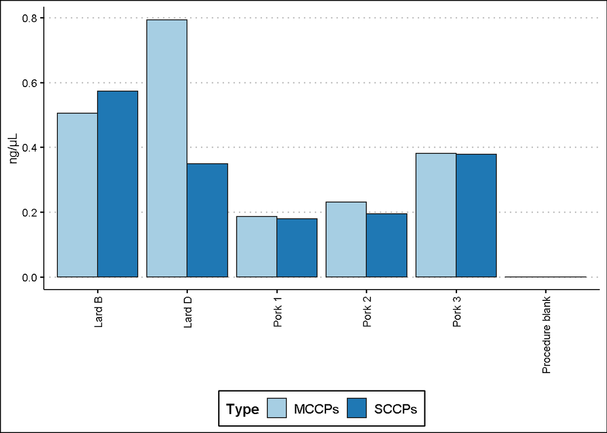

### Concentration of SCCPs, MCCPs and LCCPs (without blank subtraction)

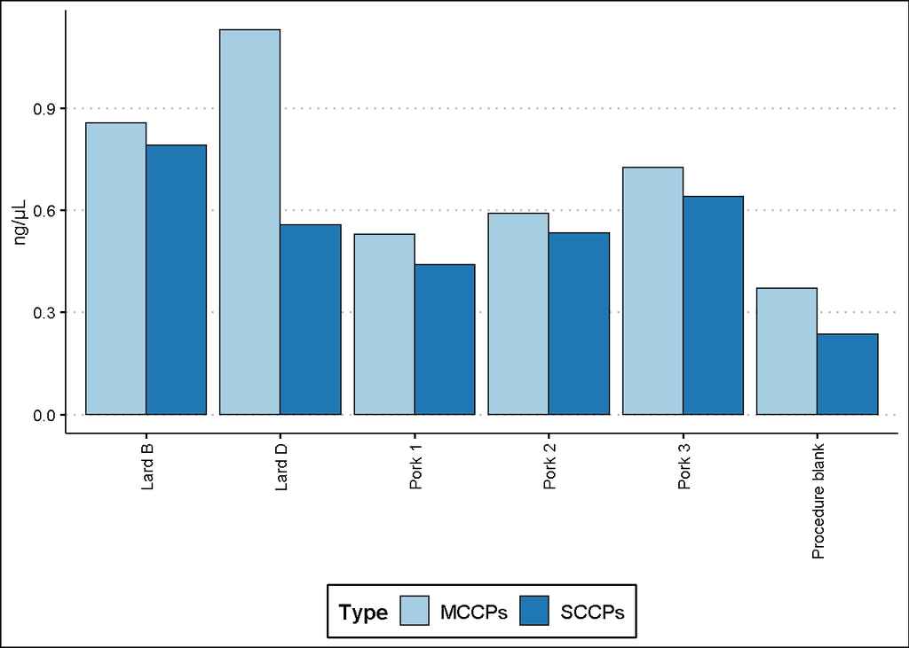

### Concentration of CP homologue groups (by chain length, blank subtracted)

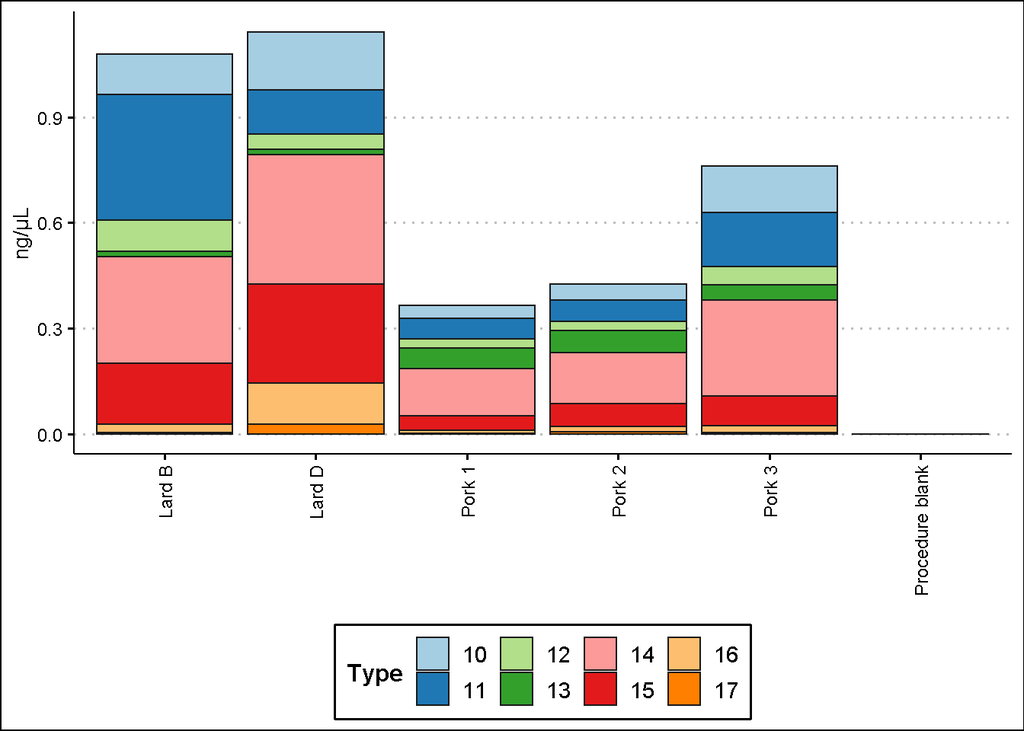

### Concentration of CP homologue groups (by chain length, without blank subtraction)

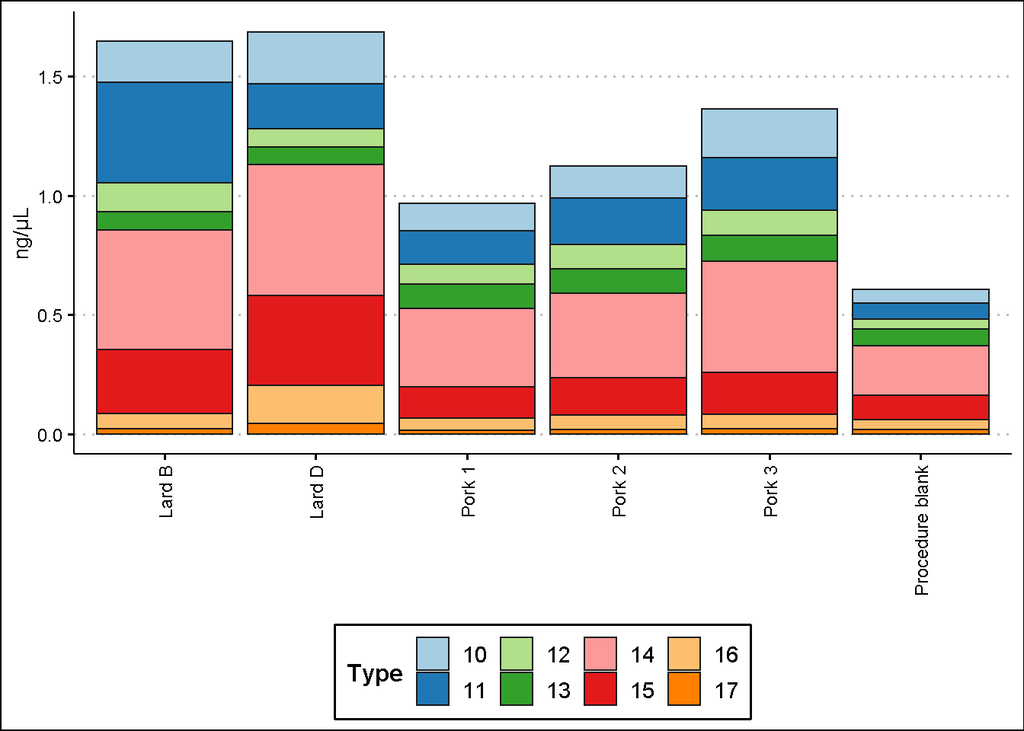

## Visualize homologue profiles

Enter sample name/-s (up to 5 samples):

```r
Sample.name.select = c("Lard B","Lard D","Pork 1")
```

### Visualize peak realative distribution within each Cn CP homologue groups (%, blank subtracted)

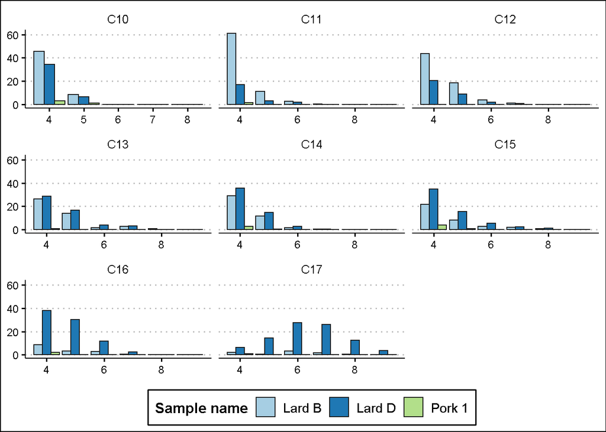

### Visualize peak realative distribution within each Cn CP homologue groups (%, without blank subtraction)

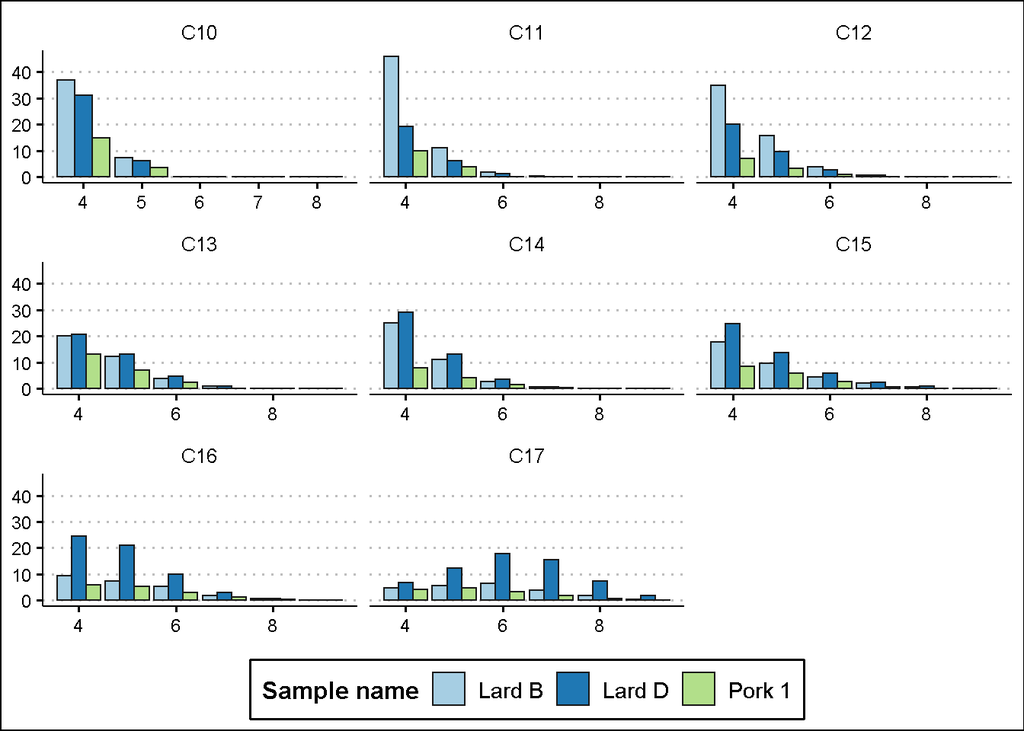

### Visualize peak area distribution (absolute peak areas, blank subtracted)

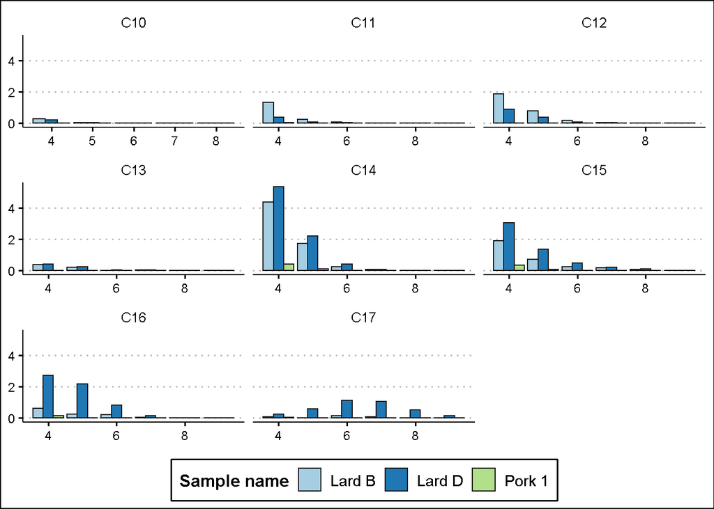

### Visualize peak area distribution (absolute peak areas, without blank subtraction)

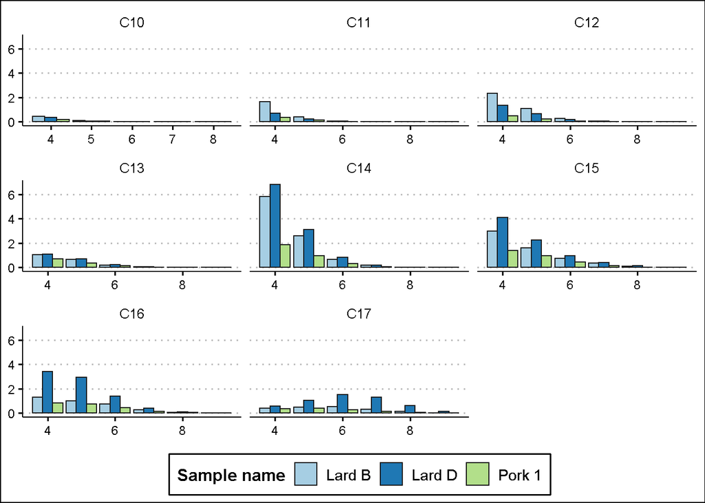